# H06 daily metrics — bounded timing-repair pilot

Participant-cluster HC3 candidate route and diagnostic sensitivities

Published

August 12, 2026

**ImportantH06-D-G2P-TIMING-REPAIR — author stop gate**

# 1 What was repaired

The first non-L10 pilot used Gaussian mixed-model diagnostics that treated remaining serial/site residual thresholds as acceptance requirements. This bounded repair leaves every participant-day outcome and predictor unchanged. It instead estimates the fixed mean structure with `stats::lm()` and uses participant-cluster HC3 covariance:

```r
response_value ~ site
response_value ~ site + predictor
response_value ~ site * predictor

sandwich::vcovCL(
  model,
  cluster = ~ participant_key,
  type = "HC3",
  cadjust = TRUE,
  fix = FALSE
)
```

The covariance allows heteroscedasticity and arbitrary dependence among a participant’s retained days. Therefore, the residual-lag thresholds remain useful descriptions but are not an independence requirement for this candidate route. The Student-t and no-nugget AR models are diagnostic sensitivities only; their p-values are never substituted.

# 2 Exact frames and candidate-model gate

All 34 expanded input-contract rows verify. The 12 frame objects match their authorized hashes and retain nine sites, one row per participant-day, sum-to-zero site contrasts, and the fixed clock encodings. M10 midpoint, first timing, and last timing use the audited continuous clock hours. L10 midpoint uses the fixed after-16:00 night-centred unwrap.

Table 1: Exact primary near-eye timing-repair frames.

| Predictor | Participant-days | Participants | Sites | Clock support | Frame identity |
| --- | --- | --- | --- | --- | --- |
| Midpoint of the brightest 10 hours |  |  |  |  |  |
| Work/free day | 784 | 141 | 9 | Pass | PASS |
| Daily activity status | 734 | 137 | 9 | Pass | PASS |
| Previous-night sleep duration | 784 | 141 | 9 | Pass | PASS |
| Midpoint of the darkest 10 hours |  |  |  |  |  |
| Work/free day | 784 | 141 | 9 | Pass | PASS |
| Daily activity status | 734 | 137 | 9 | Pass | PASS |
| Previous-night sleep duration | 784 | 141 | 9 | Pass | PASS |
| First timing above 250 lx melEDI |  |  |  |  |  |
| Work/free day | 701 | 140 | 9 | Pass | PASS |
| Daily activity status | 658 | 136 | 9 | Pass | PASS |
| Previous-night sleep duration | 701 | 140 | 9 | Pass | PASS |
| Last timing above 250 lx melEDI |  |  |  |  |  |
| Work/free day | 661 | 141 | 9 | Pass | PASS |
| Daily activity status | 626 | 137 | 9 | Pass | PASS |
| Previous-night sleep duration | 661 | 141 | 9 | Pass | PASS |

All 36 reduced/additive/interaction candidate mean models are full rank. All 36 HC3 covariance matrices are finite, symmetric, positive semidefinite, and usable without `fix = TRUE`; there are no covariance warnings. Maximum observation leverage is 0.347. The largest participant cluster accounts for at most 3.9% of total leverage in any fitted mean structure.

# 3 Candidate estimates — pilot only

The following are pointwise 95% confidence intervals with the participant- cluster-minus-one t reference. They are shown to verify the candidate route, not to make scientific claims. All p-values are raw pilot values; none was adjusted, bolded, or entered into a 15-slot family.

Table 2: Candidate HC3 timing contrasts and raw pilot tests.

| Predictor | Contrast | Estimate, h | Pointwise 95% CI, h | Association p (raw pilot) | Predictor × site p (raw pilot) |
| --- | --- | --- | --- | --- | --- |
| Midpoint of the brightest 10 hours |  |  |  |  |  |
| Work/free day | Free day minus Work day | 0.71 | 0.44 to 0.99 | <0.001 | 0.866 |
| Daily activity status | Active minus Sedentary | -0.29 | -0.63 to 0.05 | 0.097 | 0.492 |
| Previous-night sleep duration | Per 1 h greater previous-night sleep duration | 0.23 | 0.14 to 0.33 | <0.001 | 0.784 |
| Midpoint of the darkest 10 hours |  |  |  |  |  |
| Work/free day | Free day minus Work day | 0.57 | 0.32 to 0.83 | <0.001 | 0.141 |
| Daily activity status | Active minus Sedentary | -0.31 | -0.63 to 0.01 | 0.060 | 0.315 |
| Previous-night sleep duration | Per 1 h greater previous-night sleep duration | 0.17 | 0.08 to 0.27 | <0.001 | 0.142 |
| First timing above 250 lx melEDI |  |  |  |  |  |
| Work/free day | Free day minus Work day | 1.23 | 0.87 to 1.59 | <0.001 | 0.221 |
| Daily activity status | Active minus Sedentary | -0.28 | -0.85 to 0.29 | 0.330 | 0.441 |
| Previous-night sleep duration | Per 1 h greater previous-night sleep duration | 0.47 | 0.33 to 0.61 | <0.001 | 0.581 |
| Last timing above 250 lx melEDI |  |  |  |  |  |
| Work/free day | Free day minus Work day | -0.82 | -1.21 to -0.43 | <0.001 | 0.578 |
| Daily activity status | Active minus Sedentary | 0.51 | 0.01 to 1.02 | 0.048 | 0.485 |
| Previous-night sleep duration | Per 1 h greater previous-night sleep duration | -0.13 | -0.28 to 0.02 | 0.092 | 0.519 |

PILOT_RAW_ONLY_NO_BH_UPDATE; adjusted p-values are missing by design.

# 4 Diagnostic sensitivities

All 36 Student-t fixed-mean fits converge with positive-definite Hessians. For the overall predictor association, 11 of 12 shifts are below one HC3 SE. First timing above 250 lx melEDI for work/free day shifts by 1.23 HC3 SE and is a major limitation.

Nine of 12 additive no-nugget AR fits converge. Among them, eight overall association shifts are stable. L10-midpoint activity shifts by 1.26 HC3 SE and is a major limitation. The M10-sleep, first-timing-work/free, and last-timing-work/free additive AR checks did not converge; their shifts are not used and their diagnostic status is unresolved.

Table 3: Effect-shift classifications for the two diagnostic sensitivities.

| Predictor | Student-t association | AR association | Student-t site heterogeneity | AR site heterogeneity |
| --- | --- | --- | --- | --- |
| Midpoint of the brightest 10 hours |  |  |  |  |
| Work/free day | Stable (<1 SE, no reversal) | Stable (<1 SE, no reversal) | Stable (<1 SE, no reversal) | Unstable (reversal or ≥2 SE) |
| Daily activity status | Stable (<1 SE, no reversal) | Stable (<1 SE, no reversal) | Unstable (reversal or ≥2 SE) | Unstable (reversal or ≥2 SE) |
| Previous-night sleep duration | Stable (<1 SE, no reversal) | Unresolved — fit did not converge | Unstable (reversal or ≥2 SE) | Unstable (reversal or ≥2 SE) |
| Midpoint of the darkest 10 hours |  |  |  |  |
| Work/free day | Stable (<1 SE, no reversal) | Stable (<1 SE, no reversal) | Unstable (reversal or ≥2 SE) | Unresolved — fit did not converge |
| Daily activity status | Stable (<1 SE, no reversal) | Major limitation (1–<2 SE) | Stable (<1 SE, no reversal) | Unresolved — fit did not converge |
| Previous-night sleep duration | Stable (<1 SE, no reversal) | Stable (<1 SE, no reversal) | Unstable (reversal or ≥2 SE) | Unstable (reversal or ≥2 SE) |
| First timing above 250 lx melEDI |  |  |  |  |
| Work/free day | Major limitation (1–<2 SE) | Unresolved — fit did not converge | Unstable (reversal or ≥2 SE) | Stable (<1 SE, no reversal) |
| Daily activity status | Stable (<1 SE, no reversal) | Stable (<1 SE, no reversal) | Unstable (reversal or ≥2 SE) | Unresolved — fit did not converge |
| Previous-night sleep duration | Stable (<1 SE, no reversal) | Stable (<1 SE, no reversal) | Unstable (reversal or ≥2 SE) | Unresolved — fit did not converge |
| Last timing above 250 lx melEDI |  |  |  |  |
| Work/free day | Stable (<1 SE, no reversal) | Unresolved — fit did not converge | Unstable (reversal or ≥2 SE) | Unresolved — fit did not converge |
| Daily activity status | Stable (<1 SE, no reversal) | Stable (<1 SE, no reversal) | Unstable (reversal or ≥2 SE) | Stable (<1 SE, no reversal) |
| Previous-night sleep duration | Stable (<1 SE, no reversal) | Stable (<1 SE, no reversal) | Unstable (reversal or ≥2 SE) | Unstable (reversal or ≥2 SE) |

The site-heterogeneity sensitivity is weaker than the association sensitivity. Ten of 12 Student-t interaction comparisons and five of seven converged AR interaction comparisons contain at least one direction reversal under the prespecified rule. Five AR interaction fits are unresolved because they do not converge. This does not replace the robust candidate interaction test, but it precludes an unqualified timing site-heterogeneity claim.

# 5 Residual plots for author judgment

Each row is one predictor. The left panel is the candidate-model normal Q–Q plot; the middle panel is candidate residual versus fitted clock hour; the right panel shows residual pairs from the diagnostic no-nugget AR fit. Point colours follow the submitted site palette. The image source data are paired CSVs in `artifacts/10_source_data/H06_daily/`.

## 5.1 Midpoint of the brightest 10 hours

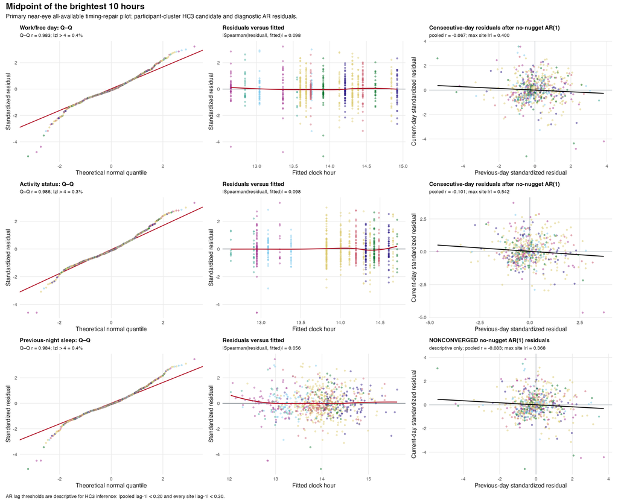

Figure 1: Residual diagnostics for the midpoint of the brightest 10 hours.

## 5.2 Midpoint of the darkest 10 hours

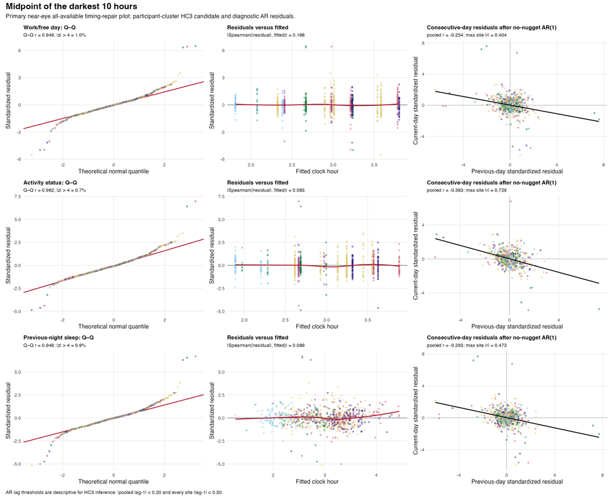

Figure 2: Residual diagnostics for the midpoint of the darkest 10 hours.

## 5.3 First timing above 250 lx melEDI

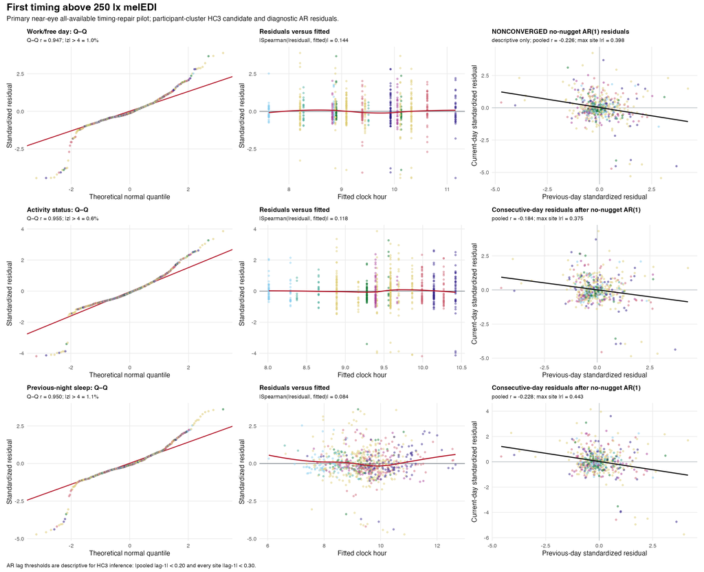

Figure 3: Residual diagnostics for first timing above 250 lx melEDI.

## 5.4 Last timing above 250 lx melEDI

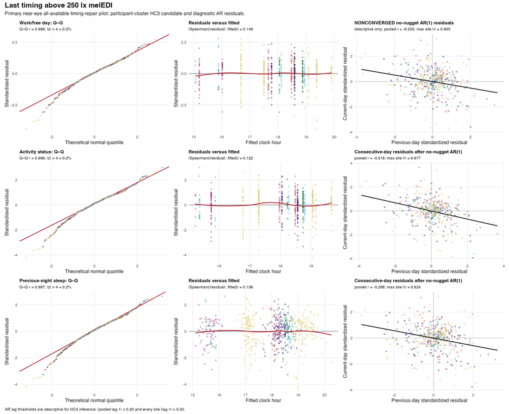

Figure 4: Residual diagnostics for last timing above 250 lx melEDI.

The visual verdict is consistent with the numerical diagnostics: L10 and first timing have the most consequential tail departures; M10 has milder curvature; last timing is closest to linear in Q–Q space. All four retain site-specific residual dependence after the diagnostic AR fit. For HC3 this dependence is descriptive, while the interaction-coefficient instability is a substantive limitation for site-heterogeneity interpretation.

# 6 Runtime, preservation, and gate recommendation

The bounded serial pilot fitted 108 models in 6.46 seconds. A mechanical extension of this timing route across the 12 already declared scenario roles is projected at 77.6 seconds. This projection does not authorize production. The earlier 50-refit pilot remains the only deletion runtime evidence; no deletion, bootstrap, or simulation was run here.

All 571 protected pre-existing H06_daily files remained byte-identical. No L10-mean, MDER, temporal GAMM, pre-sleep, main-H06, shared, Stage 3, or Stage 4 artifact changed. No BH family or adjusted p-value changed.

The recommended disposition is:

1. accept the participant-cluster HC3 route for later production of all four timing outcomes because all 12 candidate cells pass the uniform source, rank, covariance, and numerical contract;
2. carry the first-timing work/free Student-t shift and L10-activity AR shift as major limitations, and retain the three nonconverged additive AR checks as unresolved diagnostics;
3. retain the robust predictor-by-site tests and their named multiplicity slots if production is approved, but label timing site heterogeneity sensitivity-dependent and make no unqualified claim when diagnostic coefficients reverse or the AR fit does not converge; and
4. keep every pilot p-value nonconfirmatory until the complete production grid is explicitly authorized, fitted, diagnosed, and adjusted in its declared 15-slot family.

**WarningStop — explicit author decision required**

This report stops at `H06-D-G2P-TIMING-REPAIR`. Accepting the recommendation would authorize neither computation nor reporting by itself. The next action requires a separate author decision on the complete remaining non-L10 production grid, including its full diagnostic/deletion workload and the 12 declared BH families.

# 7 Reproducibility record

The authoritative scientific and display commands were:

```
Rscript --vanilla scripts/hypotheses/H06_daily/run_h06_daily_timing_repair_pilot.R
Rscript --vanilla scripts/hypotheses/H06_daily/make_h06_daily_timing_repair_residual_plots.R
```

R 4.6.1 and the synchronized project library were used. The report reads only sealed CSV/PNG artifacts and verifies their manifests. It performs no fit, diagnostic recomputation, p-value adjustment, deletion, bootstrap, or simulation.

Table 4: Measured bounded-pilot runtime.

| Component | Models/calculations | Elapsed, s | Role | 12-role timing projection, s |
| --- | --- | --- | --- | --- |
| Candidate fixed-site LM | 36 | 0.016 | candidate mean structures | — |
| Participant-cluster HC3 covariance | 36 | 0.168 | candidate covariance calculations | — |
| Student-t identity sensitivity | 36 | 0.488 | diagnostic only | — |
| No-nugget gap-aware AR sensitivity | 36 | 4.040 | diagnostic only | — |
| Complete bounded serial pilot | 108 | 6.463 | measured wall time | 77.6 |